# Agentes Inteligentes

Universidad Austral

Claude Cowork

Autor: Paulo Veiga y Marco Sánchez Sorondo  
Última modificación: Julio 2026

01Claude Cowork 02Knowledge & Output 03Projects 04Skills 05Subagentes 06Conclusions 07La misión · parte 2

01

Claude Cowork

Claude Cowork

## Cowork, de propósito general

### Cowork

Claude instalado en la computadora, trabajando sobre las carpetas y archivos del usuario.

### La herramienta de propósito general del knowledge worker

El "lenguaje de programación" es el español.

### "El nuevo Excel"

Hay analistas que la llaman **"el nuevo Excel"**: la habilidad base del trabajo de oficina para los próximos años (encuadre de la industria, no de Anthropic).

**Anthropic**: **"Claude Code para el resto de tu trabajo"**.

Claude Cowork

## De chatear a delegar

Lo que cambia ahora es el rol: **delegar**. ¿Qué delegamos? Chatear vs delegar:

ChatearDelegar a un agente

La forma de trabajoUn mensaje a la vezSe describe un resultado

Los pasosLos hace la personaEl agente planifica y ejecuta

La salidaTexto en la ventanaArchivos en el disco

El rol humanoHacer cada paso intermedioRevisar el plan y corregir el rumbo

[figure not shown]

Claude Cowork

## El mapa: piezas que se apilan

**Idea clave:** cada bloque resuelve un problema conocido y se apila sobre el anterior; cada tarea usa solo los que necesita.

[figure not shown]

Claude Cowork

## Dónde se empieza en Cowork

[figure not shown]

01Claude Cowork 02Knowledge & Output 03Projects 04Skills 05Subagentes 06Conclusions 07La misión · parte 2

02

Knowledge & Output

Knowledge & Output

## Qué lee el agente en la carpeta

1

Delegar un resultado significa que el agente trabaja sobre la carpeta. **Lee** el material que hay ahí y **escribe** ahí mismo sus entregables y sus notas.

2

Y lo que hay en la carpeta es, casi siempre, **conocimiento e instrucciones**. Notas, material de referencia, cómo se hace acá cada tarea.

3

Ese material necesita un formato pensado para que **lo lea la máquina**. Las apps de notas están hechas para lectura humana.

Knowledge & Output

## Qué es un .md: el texto y lo que se ve

- Un `.md` (Markdown) = **texto plano** + unas pocas marcas de estructura: `#` para títulos, `-` para listas, `**negrita**`, `|` para tablas.
- Se escribe y se lee con **cualquier editor de texto**, en cualquier computadora, sin formato propietario. Y la IA lo lee nativo: está entrenada para entender esas marcas.
- Además puede llevar arriba una **metadata (header YAML)** que declara *qué es* el archivo y *cuándo* usarlo. Vuelve con las Skills (sección 4).

[figure not shown]

Knowledge & Output

## Iterar en .md, exportar al final

**Idea clave:** con la IA nada sale bien a la primera. El trabajo son **muchas vueltas** sobre el mismo archivo, y el `.md` es el formato donde esa vuelta sale barata.

### Cada vuelta es un pedido chico

Sobre el archivo que ya existe: *"sumá la región Sur"*, *"acortá el resumen a cinco líneas"*, *"poné la tabla antes del texto"*.

### En `.md` nada se rompe

En `.md` la IA **reescribe el archivo entero sin romper nada**, porque ve la estructura directa. En `.docx`/`.xlsx` cada vuelta atraviesa capas de formato y se degrada.

### Regla de bolsillo

*Se itera en `.md` y se entrega en el formato que pida el destinatario.*

### El entregable, una sola vez

El entregable se genera **una sola vez, al final**: `.docx`, PDF o slides salen de un único pedido cuando el trabajo ya está.

[figure not shown]

01Claude Cowork 02Knowledge & Output 03Projects 04Skills 05Subagentes 06Conclusions 07La misión · parte 2

03

Projects

Projects

## Qué es un Project

### Project

Espacio de trabajo autocontenido: **carpeta propia + memoria + instrucciones**.

### Un ejemplo de oficina

**"Informe mensual del equipo"**, apuntado a la carpeta `Documentos/Informe-Mensual`.

### Tres capas persistentes

Instrucciones · Knowledge base · Chats.

### Los chats no comparten contexto

Los chats del Project **no comparten contexto entre sí** (solo la base de conocimiento).

Projects

## Conceder una carpeta y ver el contexto

[figure not shown]

Projects

## ¿Los lee todos?

**Cuando se le dan archivos a la IA, ¿los lee todos?** Dos formas de trabajar, y cuál conviene en cada caso. Y **tres reglas prácticas**.

### Pocos archivos

Claude los lee completos, todos, cada vez que llega una pregunta. Máxima precisión, a costa de ocupar la ventana de contexto entera en cada vuelta.

### Muchos archivos

Claude cambia solo de estrategia. En lugar de leer todo, busca y trae los fragmentos que hacen falta. Multiplica por 10 la capacidad del Project, y la respuesta pasa a apoyarse en esos fragmentos.

### Trabajar sobre los archivos

Consultarlos no alcanza. Claude abre, modifica y guarda dentro de la carpeta concedida, como lo haría una persona.

### Regla · Subir lo que importa

El relleno "por las dudas" empeora las respuestas.

### Regla · Nombres de archivo claros

Un nombre que no dice qué hay adentro tampoco le sirve a la IA.

### Regla · PDFs escaneados

Sin capa de texto son imágenes vacías. Conviene convertirlos antes.

Projects

## Instrucciones: el contrato de trabajo

### El contrato de trabajo

Instrucciones = el **"contrato de trabajo"**: reglas en lenguaje natural que aplican a todo el Project.

### Se escriben una vez

El usuario las escribe **una vez** y valen para todos los chats.

### Cortas y claras

Conviene que sean **cortas y claras**. Es el lugar de las **reglas no negociables**.

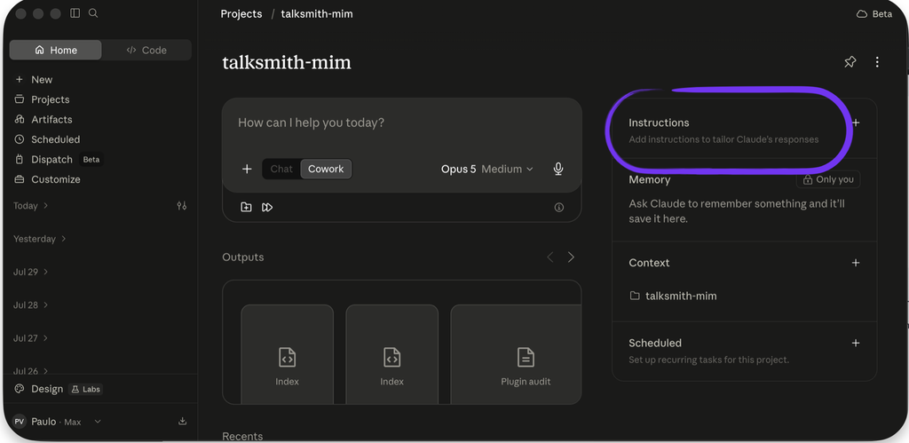

Projects

## Un ejemplo de Instrucciones

```
Sos el asistente de informes del equipo comercial.
Preparás el informe mensual para colegas NO técnicos (incluido el jefe),
que se lee en 5 minutos antes de la reunión de cierre de mes.

· Regiones que cubrís: Norte, Centro y Sur.
· Escribís en español, claro y breve, sin jerga.
  Si usás un término técnico, lo explicás en una línea.
· Trabajás con las notas que están en la carpeta notas/.
· REGLA DE ORO: toda cifra lleva su fuente y su fecha.
  NUNCA publicás un número sin decir de dónde salió.
  Si el dato no está en las notas, lo aclarás en el informe.
```

01Claude Cowork 02Knowledge & Output 03Projects 04Skills 05Subagentes 06Conclusions 07La misión · parte 2

04

Skills

Skills

## Qué es una Skill

*"Todo lo que le explicás a Claude más de una vez es una Skill que deberías escribir una vez."*

### Es un instructivo escrito

Una tarea explicada en pasos, guardada en un archivo. Se escribe en español, no es código.

### Se enseña una vez

Después la tarea se pide y sale siempre igual: mismos pasos, mismo formato de salida.

### Un trabajo por Skill

Si al describirla aparece un "y además", son dos Skills.

### Queda disponible

Vive en la lista de Habilidades y está a mano en cualquier chat, no dentro de uno.

**Ejemplo del que vamos a hablar toda la sección**: La Skill `informe-mensual` lee la carpeta `notas/` y devuelve el informe del mes con el formato de siempre.

Skills

## Cómo se usa una Skill

Una vez guardada y habilitada, una Skill se usa de **dos formas**.

### Explícita

Se tipea `/` en el chat y se elige la Skill como comando. Ejemplo: `/informe-mensual`.

### Automática

Se pide la tarea en español y Claude reconoce que el pedido coincide con la **descripción** de la Skill, y la carga solo. Ejemplo: *"armame el informe de mayo con lo que hay en `notas/`"*.

Por eso la **descripción** de una Skill importa tanto: es lo que decide si se dispara sin que nadie la nombre.

[figure not shown]

Skills

## Tres formas de crear una Skill

Cuando la Skill que hace falta no existe todavía, hay tres caminos para crearla.

### Desde el panel

Configuración → Habilidades → Agregar. Dos entradas crean una Skill nueva. "Crear con Claude" la arma en un ida y vuelta de chat y "Escribir las instrucciones" se edita directo en la interfaz. Es el camino explícito, donde se ve cada paso.

### Desde el prompt

Se abre un chat y se describe lo que se quiere. Claude pregunta por el proceso, arma la Skill y la empaqueta. Es el camino con menos fricción para quien ya está trabajando.

### Grabando la pantalla

Se hace la tarea narrándola en voz alta, Claude mira la grabación y propone la Skill. Es la barrera más baja de las tres, porque no hay nada que escribir.

**Los tres terminan en la misma compuerta**: Guardar y habilitar la Skill en la lista de Habilidades, o parece que "no funciona".

Skills

## Metodo 1: Crear desde el panel

[figure not shown]

Skills

## Metodo 2: Crear desde el prompt

1

#### Se describe lo que se quiere

Se abre un chat nuevo y se pide la Skill en una línea, por ejemplo *"quiero armar una Skill para el informe mensual del equipo"*.

2

#### Claude pregunta por el proceso

Hay que contarlo con el detalle que necesitaría alguien capaz que nunca hizo esa tarea. También pregunta por los casos de uso concretos y por cómo se reconoce un buen resultado.

3

#### Se le suben los materiales

En la misma conversación entran las plantillas, los ejemplos de trabajos anteriores, las guías de estilo y los archivos de datos.

4

#### Claude arma la Skill

Escribe el `SKILL.md`, el archivo de instrucciones que toda Skill necesita, ordena los materiales que recibió y genera el código de las operaciones descritas. No hay ningún comando que tipear.

5

#### Se prueba

Se le pide una tarea que la Skill debería resolver. Si se activó, aparece **"Usando [nombre de la Skill]"** en el razonamiento de Claude. Si algo no cierra, se le pide el ajuste a Claude y se prueba de nuevo.

**Antes de probar, la compuerta de siempre**: Guardar y habilitar en Configuración → Capacidades → Habilidades, o parece que "no funciona".

Skills

## Metodo 3: Crear grabando una Skill

### Tercer camino de creación

Grabar la pantalla mientras se hace la tarea y narrarla en voz alta. Claude mira la grabación y propone la Skill.

### Dónde

El botón **"+"** del compositor del chat, en **"Record a skill"**; también en Configuración → Habilidades → Agregar → "Grabá tu pantalla", la cuarta entrada del menú de la lámina 4.4.

### Para qué sirve

La tarea que uno ya hace de memoria y le costaría escribir en pasos. Es el camino con la barrera más baja de los tres.

### Qué captura

Pantalla, clicks, tipeo y voz, hasta unos 10 minutos.

### Cuidado

No tipear contraseñas ni información sensible mientras corre la grabación.

### Disponibilidad

Planes Pro, Max y Team, en Cowork en Claude para Mac.

[figure not shown]

01Claude Cowork 02Knowledge & Output 03Projects 04Skills 05Subagentes 06Conclusions 07La misión · parte 2

05

Subagentes

Subagentes

## Subagentes: varios trabajando a la vez

### Subagente

Asistente aislado, contexto propio; devuelve **un resumen** (no la transcripción).

### Ejemplo

**8 propuestas de proveedores**, un subagente por propuesta; los 8 corren en paralelo y el agente principal arma la tabla comparativa final.

### Corren por debajo

En Cowork corren "por debajo", **varios en paralelo**.

### No se configuran a mano

Los coordina Claude solo, según la tarea. No hay panel de subagentes en Cowork.

### Lo que sí está en la mano del usuario

**Pedir el trabajo en partes separables** ("compará estas 8 propuestas"), que es lo que habilita el paralelo.

[figure not shown]

Subagentes

## Armar un subagente propio

**En Cowork no hay un botón de "crear subagente".** Un subagente es un archivo de texto, y para que quede disponible siempre se lo empaqueta en un **plugin**.

### Es un archivo `.md`

Arriba, un encabezado con cuatro campos: `name`, `description`, `tools` y `model`. Abajo, en prosa, las instrucciones del asistente.

### La `description` es el disparador

Es lo único que decide cuándo Claude lo delega. Conviene ser explícito: *"usar cuando el usuario pida una revisión"*.

### Corre aparte

Ventana de contexto propia, sus instrucciones, sus herramientas. Devuelve el resumen, no la transcripción.

### Para que persista, un plugin

Los archivos de una sesión de Cowork no le sobreviven. Un plugin —manifiesto `plugin.json` + carpeta `agents/`— los deja instalados y disponibles siempre, junto con las Skills y conectores que se le sumen.

**No confundir con la lámina anterior**: Para paralelizar, Claude lanza subagentes **solo**, sin que nadie configure nada. Esto es el otro caso: cuando uno quiere un asistente **propio**, con instrucciones fijas, disponible siempre.

Subagentes

## Un subagente, por dentro

Así se ve el archivo completo. Arriba el encabezado, abajo las instrucciones en prosa.

**Nadie escribe esto a mano:** se le pide a Claude que lo escriba, y se revisa que la `description` diga bien cuándo usarlo.

Markdown

```markdown
---
name: revisor-de-informes
description: Revisa un informe y marca cifras sin fuente. Usar cuando pidan una revisión.
tools: Read, Grep, Glob
model: sonnet

---

Sos un revisor de informes. Para cada problema: nombrá la cifra,
mostrá dónde está y proponé la corrección.
```

01Claude Cowork 02Knowledge & Output 03Projects 04Skills 05Subagentes 06Conclusions 07La misión · parte 2

06

Conclusions

Conclusions

## Lo que se llevan: cambió el rol

### El rol cambió

Ahora se delega un resultado completo y se guía el proceso mientras corre.

### Las piezas, al servicio de eso

Los archivos `.md`, el Project, las Instrucciones, las Skills y los Subagentes son piezas al servicio de eso. **Cada trabajo usa solo las que necesita.**

### El chat extendido sigue en pie

El chat extendido de la clase anterior sigue en pie y ahora se le suma la computadora.

### Barrera de entrada en cero

La barrera de entrada está en cero: se opera en español y no hace falta escribir código.

**Para el lunes**: Elegir una tarea propia que se repite todas las semanas y armarla una sola vez, para que después corra sola.

Conclusions

## Antes de cerrar: cuidados

### Toda salida es un borrador

Cifras, citas y afirmaciones se verifican contra la fuente.

### Nada de datos de clientes, financieros, PII ni bajo NDA

La actividad de Cowork no queda en el registro de auditoría estándar: solo hay rastro si la organización lo configura aparte (Team/Enterprise), y por defecto no se registra nada.

### Capas de guardarraíles

Permisos de carpeta → reglas en Instrucciones → solo conectores verificados → revisión humana.

01Claude Cowork 02Knowledge & Output 03Projects 04Skills 05Subagentes 06Conclusions 07La misión · parte 2

07

La misión · parte 2

La misión · parte 2

## La misión, parte 2: Faro en Cowork

### Parte 2, en Cowork

Faro baja a la computadora y trabaja sobre la carpeta real del equipo.

### Las piezas de esta mitad

**Projects, Instrucciones, archivos `.md`, Skills y Subagentes.**

### El entregable final

Es **el tablero para el jefe**: se arma en `.md` y se exporta al formato de entrega, con el flujo de la sección 2.

### No hace falta haber resuelto la parte 1

De la clase anterior: la parte 2 arranca del material que ya viene con la misión.